# Anexo 11

### Proyecto 11: Detector de Spam

Mg. Luis Felipe Bustamante Narváez

Este proyecto se desarrollará utilizando una base de datos sintética creada a través de ChatGPT con base en datasets extraídos en inglés de diferentes repositorios. Esto debido a, no tener muchas fuentes de gran tamaño de correos electrónicos en español, y no poder hacer uso de ciertas bases de datos por motivos de seguridad. Además, se utilizará una base de datos tomada de kaggle, donde se muestran correos en inglés, para validar que sin importar el idioma, se cumple con el objetivo.

Para desarrollar este ejercicio, usaremos Naive Bayes, con el fin de clasificar si un correo electrónico es o no, spam.

## Librerías

```python
pip install seaborn -q
```

```python
pip install wordcloud -q
```

```python
import numpy as np
import pandas as pd
import seaborn as sn
import matplotlib.pyplot as plt
from sklearn.feature_extraction.text import TfidfVectorizer, CountVectorizer
from sklearn.model_selection import train_test_split
from sklearn.metrics import roc_auc_score, f1_score, confusion_matrix
from sklearn.naive_bayes import MultinomialNB
from wordcloud import WordCloud  #Mostrar gráfico de palabras
```

## Cargamos los datos

```python
opcion = int(input('Ingrese 1 para los correos en español y 2 para los correos en inglés:'))

if opcion == 1:
    path = 'data/spam.csv'
    df = pd.read_csv(path, encoding='utf-8')
elif opcion == 2:
    path = 'data/spam_or_not_spam.csv'
    df = pd.read_csv(path, encoding='ISO-8859-1')
    df.rename(columns={'email':'contenido', 'label':'spam'}, inplace=True)
    #encontramos una cadena NAN  df[df.isna().any(axis=1)]
    df['contenido'] = df['contenido'].fillna('')  #La reemplazamos por cadena vacía
else:
    print('Opción no válida')
```

```python
df
```

|  | contenido | spam |
| --- | --- | --- |
| 0 | date wed NUMBER aug NUMBER NUMBER NUMBER NUMB... | 0 |
| 1 | martin a posted tassos papadopoulos the greek ... | 0 |
| 2 | man threatens explosion in moscow thursday aug... | 0 |
| 3 | klez the virus that won t die already the most... | 0 |
| 4 | in adding cream to spaghetti carbonara which ... | 0 |
| ... | ... | ... |
| 2995 | abc s good morning america ranks it the NUMBE... | 1 |
| 2996 | hyperlink hyperlink hyperlink let mortgage le... | 1 |
| 2997 | thank you for shopping with us gifts for all ... | 1 |
| 2998 | the famous ebay marketing e course learn to s... | 1 |
| 2999 | hello this is chinese traditional å ä»¶ NUM... | 1 |

3000 rows × 2 columns

```python
df['contenido'][0][:500]
```

```
' date wed NUMBER aug NUMBER NUMBER NUMBER NUMBER NUMBER from chris garrigues cwg dated NUMBER NUMBERfaNUMBERd deepeddy com message id NUMBER NUMBER tmda deepeddy vircio com i can t reproduce this error for me it is very repeatable like every time without fail this is the debug log of the pick happe…
```

```python
df['spam'][0]
```

```
0
```

```python
# Agrupamos para obtener el total de datos  (0-> ham, 1->spam)
grouped = df.groupby('spam').count()
grouped
```

| spam | contenido |
| --- | --- |
| 0 | 2500 |
| 1 | 500 |

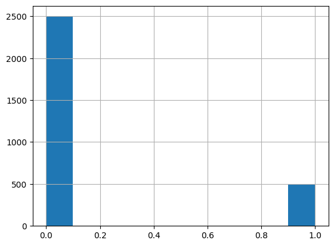

```python
# Gráfico de histograma de la población
df['spam'].hist()
```

```python
# Convertimos la columna spam en un arreglo
Y = df['spam'].to_numpy()
```

```python
Y
```

```
array([0, 0, 0, ..., 1, 1, 1], dtype=int64)
```

## Procesamiento de Datos

### Entrenamiento

```python
# Dividimos los datos en conjuntos de entrenamiento y de prueba
df_train, df_test, Y_train, Y_test = train_test_split(df['contenido'], Y, test_size=0.2)
```

```python
df_train
```

```
244      zimbabwe has dropped objections to accepting ...
1157    on wed aug NUMBER NUMBER at NUMBER NUMBER ulis...
2418    url URL date NUMBER NUMBER NUMBERtNUMBER NUMBE...
171     david asked my wife noticed something odd the ...
1458    on wed NUMBER sep NUMBER stephane lentz wrote ...
                              ...
294      URL an investigation has been launched after ...
1644     your mail and gives you only the non spam to ...
2648     unlimited web conferencing subscribe to the w...
2599     free adult lifetime membership limited time o...
948      from valdis kletnieks URL date mon NUMBER aug...
Name: contenido, Length: 2400, dtype: object
```

```python
df_test
```

```
1585    i m taking all my razored mail today and calli...
1495     URL jm URL changed what removed added status ...
855      original message from gary lawrence murphy ga...
1171    help i had gpg working i updated from version ...
2227    url URL date NUMBER NUMBER NUMBERtNUMBER NUMBE...
                              ...
675      help me out here you around barely but don t ...
90      hi dermot if have a look at one of the dists l...
197     hey i has just been given an old toshiba csNUM...
1506    unable to find user matt_relay sbcglobal net p...
354     on wed NUMBER NUMBER NUMBER at NUMBER NUMBER g...
Name: contenido, Length: 600, dtype: object
```

```python
len(Y_train)
```

```
2400
```